# Find_optimal_K

```python
import pylab as pl
import healpy as hp
from sklearn import preprocessing
from sklearn.neighbors import DistanceMetric
from sklearn.metrics import pairwise_distances
from sklearn.metrics.pairwise import pairwise_kernels
from sklearn.cluster import SpectralClustering
from sklearn.cluster import AgglomerativeClustering
from scipy.interpolate import interp1d
from pylab import cm
cmap = cm.get_cmap('RdYlBu')
cmap.set_under('w')
cmap2 = cm.get_cmap('tab20b')
cmap2.set_under('w')
%matplotlib inline
```

```python
from IPython.display import HTML

HTML('''<script>
code_show=true;
function code_toggle() {
 if (code_show){
 $('div.input').hide();
 } else {
 $('div.input').show();
 }
 code_show = !code_show
}
$( document ).ready(code_toggle);
</script>
<form action="javascript:code_toggle()"><input type="submit" value="Click here to toggle on/off the raw code."></form>''')
```

## Defining patches via clustering methodologies

2019-09-13  
Giuseppe

1. Consider maps of $\beta_d$ and the related uncertainties $\sigma(\beta_d)$ from [Planck Legacy Archive](http://pla.esac.esa.int/pla/aio/product-action?MAP.MAP_ID=COM_CompMap_Dust-GNILC-Model-Spectral-Index_2048_R2.01.fits)
2. From the maps of $\beta_d$ and $\sigma(\beta_d)$ estimate for each pixel the continuous probability distribution $\mathcal{P}$ assumed to be normal distribution $ \mathcal{P} \sim N( {\beta }_d ,\sigma(\beta_d))$
3. Estimate the [Hellinger distance](https://en.wikipedia.org/wiki/Bhattacharyya_distance) which is used to quantify the affinity between two probability distributions
4. Look for $K$ patches given the affinity matrix with Hierarchical clustering method.

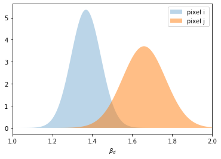

```python
x=pl.linspace(0.5, 2.5,1024)
Gauss = lambda x, mu,sigma: 1./pl.sqrt(2.*pl.pi * sigma**2) *pl.exp(-(x-mu)**2/2/sigma**2)
#pl.plot(x,Gauss(x, bd[1],ebd[1]), label='pixel 1')
#pl.plot(x, Gauss(x, bd[3000],ebd[1000]), label='pixel 100')
pl.fill_between(x, Gauss(x, bd[1],ebd[1])  ,  alpha=.3,label='pixel i')
pl.fill_between(x, Gauss(x, bd[3000],ebd[3000]) , alpha=.5,label='pixel j ')
pl.xlabel(r'$\beta_d$' )
pl.xlim([1,2])
pl.legend()
```

**Fig**Normal distribution with $\mu _i = \beta_{i}, \sigma_i = \sigma_{\beta i} $ for two pixels $i$ and $j$

Overlapping area: $$A_{ij} \equiv \int_X dx \sqrt{\mathcal{P}_i \mathcal{P}_j } $$ Hellinger distance: $$H_{ij} = \sqrt{1-A_{ij} }$$

# What is the optimal number of clusters ?

There is a trade off between the **intra** and **inter-cluster distances**. The former tends to increase with $K$ and it's defined by the minimum of the distance between cluster centroids. The latter is a quantity related to the *sizes* of clusters and how many elements belong to each cluster. Hence, intuitively, tends to *decrease* with $K$.

## Cluster similarity

- similarity including uncertainties on spectral parameters (Hellinger distance)
- similarity including spatial location (Haversine) + (Hellinger)

```python
def plotclusters(labels,imap):
    outm= pl.zeros_like(imap)
    for i in range(labels.max()+1):
        pixs=pl.where(labels==i)
        outm[pixs]=imap[pixs].mean()

    return outm

def intracluster_distance(K,X, labels  ):
    mu = pl.zeros( K*X.shape[1]).reshape(K,X.shape[1])
    MD = pl.zeros( K)
    for k in range(K):
        ck =pl.where(labels == k )[0]
        Xk =X[ck,:  ]
        mu[k] = Xk.mean(axis=0)
        Nk = len(ck)
        MD[k] = pl.linalg.norm(Xk-mu[k],axis=1).sum()/Nk
    return mu, MD

def hellinger_distance(x,y ) :
    #estimating hellinger distance from https://en.wikipedia.org/wiki/Hellinger_distance
    mu1= x[0]; sigma1=x[1];
    mu2= y[0]; sigma2=y[1] ;


    BC = (pl.sqrt(2. *sigma1*sigma2/(sigma1**2 +sigma2**2))
          * pl.exp(-1/4. *(mu1-mu2)**2/(sigma1**2 +sigma2**2)))

    return pl.sqrt(1- BC )

def setup_features(X, nside , affinity='mult'  ) :
    Npix=hp.nside2npix ( nside )
    #prepare features  Coordinates
    longi, lat= pl.deg2rad( hp.pix2ang(nside=nside ,ipix=pl.arange(Npix), lonlat=True )  )
    mask =  pl.ma.masked_inside(longi, 0 , pl.pi ).mask
    longi [  mask] =  - longi [mask]
    longi [  pl.logical_not(mask) ] =  2* pl.pi - longi [pl.logical_not ( mask) ]
    Theta= pl.array([ lat ,  longi ]).T
    #create feature vector

    Xtilde = pl.concatenate( [X , Theta ], axis=1)
    # apply MinMaxScaler
    min_max_scaler = preprocessing.MinMaxScaler()

    #Xtilde= min_max_scaler.fit_transform(Xtilde)
    # prepare Affinity  matrix =  Euclidean x Haversine distances
    haversine = DistanceMetric.get_metric('haversine')
    if nside==32:
        paramdistance_matr=pl.load('/Users/peppe/work/heavy_maps/affinity_hellinger_nside32_betadust.npy')
    else:
        hellinger = DistanceMetric.get_metric( hellinger_distance)

        paramdistance_matr=  hellinger.pairwise( Xuncertainties )

    if affinity =='mult':
        angdist_matr =haversine.pairwise( Theta  )
        angdist_matr =pl.ma.fix_invalid(angdist_matr,  fill_value=pl.pi).data
        #paramdistance_matr= pairwise_distances( X, metric='euclidean')
        angdist_matr/=angdist_matr.max()
        tot=pl.multiply ( paramdistance_matr, angdist_matr)
    else:
        Xtilde = X
        tot= paramdistance_matr
    Affinity = pairwise_kernels(tot, metric='precomputed')
    return Xtilde, Affinity
```

```python
bd=hp.read_map('COM_CompMap_Dust-GNILC-Model-Spectral-Index_32_R2.01_6deg.fits', verbose=False, field=0 )
ebd= hp.read_map('COM_CompMap_Dust-GNILC-Model-Spectral-Index_32_R2.01_6deg.fits', verbose=False, field=1 )
nside= hp.get_nside(bd)
```

```python
Xuncertainties= pl.array(  [ ( i,j) for i, j in zip (  bd ,ebd) ] )     .reshape(len(bd),2 )
Xtilde1 , Affinity1  =setup_features(Xuncertainties , nside  )
```

```python
Nfeat =  Xtilde1.shape[-1]
Nvals =  15
Kmax = 80
```

```python
Kvals=pl.linspace(2, Kmax, num=Nvals, dtype =pl.int16)
Vu=[]; Vo=[]

for K  in Kvals  :
    #print(K)
    clusters1 = AgglomerativeClustering(n_clusters=K  ,affinity= 'precomputed', linkage='average')
    clusters1.fit_predict(Affinity1)
    mu, MD = intracluster_distance(K, Xtilde1 , clusters1.labels_ )
    #print mu, MD
    dmu = pairwise_distances( mu, metric='euclidean')
    pl.fill_diagonal(dmu, pl.inf)
    vo = K/dmu.min() #intracluster distance
    vu = (MD.sum()/ K ) #intercluster distance
    Vu.append(vu )
    Vo.append(vo)
```

# Haversine + Hellinger Distance

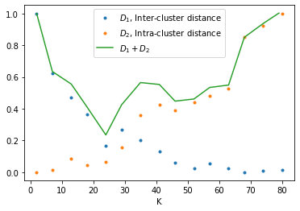

```python
Vu= pl.array(Vu)
Vu = (  Vu -Vu.min() )  /(Vu.max() -Vu.min() )
Vo = pl.array(Vo)
Vo = (  Vo -Vo.min() )  /(Vo.max() -Vo.min() )

Vsv =interp1d ( Kvals, Vu +Vo ,kind='slinear')
Ks=pl.arange(2, Kmax )
pl.plot(Kvals, Vu,'.',label=r'$D_1$, Inter-cluster distance ' )
pl.plot(Kvals, Vo ,'.',label=r'$D_2$, Intra-cluster distance ')
pl.plot(Ks, Vsv(Ks) ,'-', label=r'$D_1+D_2$ ')
pl.xlabel('K')
pl.legend()
minval  = pl.argmin ( Vsv(Ks) - Vsv(Ks).min() )
Kopt1 = Ks [minval ]
```

```python
clusters1 = AgglomerativeClustering(n_clusters=Kopt1  ,affinity= 'precomputed', linkage='average')
_= clusters1.fit_predict(Affinity1)
```

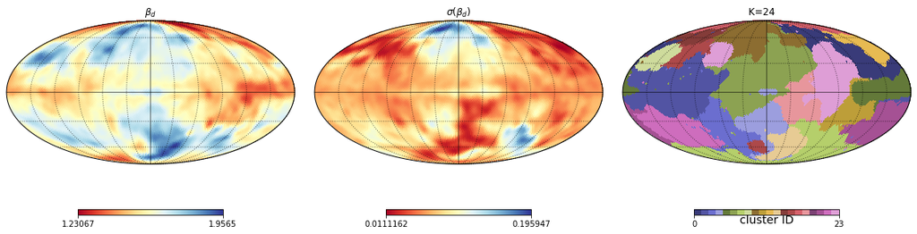

```python
pl.figure(figsize=(16,16))
hp.mollview(  Xuncertainties[:,1]    , cmap=cmap,title=r'$\sigma( \beta_d ) $'  , sub=132 )
hp.mollview( ( Xuncertainties[:,0]), title=r'$\beta_d$', cmap=cmap  , sub=131)
hp.mollview(  clusters1.labels_    , title=r'K=%d   '%Kopt1 ,   cmap=cmap2, unit='cluster ID'   , sub=133 )

hp.graticule(alpha=.6, verbose=False)
```

```python
Xtilde2 , Affinity2  =setup_features(Xuncertainties , nside , affinity='helling.' )
```

# Hellinger only distance

```python
Nfeat =  Xtilde2.shape[-1]

Vu=[]; Vo=[]

for K  in Kvals  :
    #print(K)
    clusters = AgglomerativeClustering(n_clusters=K  ,affinity= 'precomputed', linkage='average')
    clusters.fit_predict(Affinity2)
    mu, MD = intracluster_distance(K, Xtilde2 , clusters.labels_ )
    #print mu, MD
    dmu = pairwise_distances( mu, metric='euclidean')
    pl.fill_diagonal(dmu, pl.inf)
    vo = K/dmu.min()
    vu = (MD.sum()/ K )
    Vu.append(vu )
    Vo.append(vo)
```

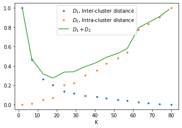

```python
Vu= pl.array(Vu)
Vu = (  Vu -Vu.min() )  /(Vu.max() -Vu.min() )
Vo = pl.array(Vo)
Vo = (  Vo -Vo.min() )  /(Vo.max() -Vo.min() )

Vsv =interp1d ( Kvals, Vu +Vo )
Ks=pl.arange(2, Kmax )
pl.plot(Kvals, Vu,'.',label=r'$D_1$, Inter-cluster distance ' )
pl.plot(Kvals, Vo ,'.',label=r'$D_2$, Intra-cluster distance ')
pl.plot(Ks, Vsv(Ks) ,'-', label=r'$D_1+D_2$ ')
pl.xlabel('K')
pl.legend()

minval  = pl.argmin ( Vsv(Ks) - Vsv(Ks).min() )
Kopt2 = Ks [minval ]
```

```python
clusters2 = AgglomerativeClustering(n_clusters=Kopt2  ,affinity= 'precomputed', linkage='average')
_= clusters2.fit_predict(Affinity2)
```

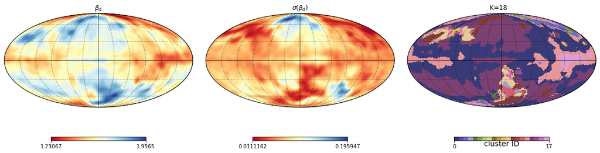

```python
pl.figure(figsize=(16,16))
hp.mollview(  Xuncertainties[:,1]    , cmap=cmap,title=r'$\sigma( \beta_d ) $'  , sub=132 )
hp.mollview( ( Xuncertainties[:,0]), title=r'$\beta_d$', cmap=cmap  , sub=131)
hp.mollview(  clusters2.labels_    , title=r'K=%d   '%Kopt2 ,   cmap=cmap2, unit='cluster ID'   , sub=133 )

hp.graticule(alpha=.6, verbose=False)
```